# Tidy Tuesday

Daniel Molitor

8/4/2020

This week’s European energy data can be found [here](https://github.com/rfordatascience/tidytuesday/blob/master/data/2020/2020-08-04/readme.md)! I wanted to focus on making an actually good-looking radial bar chart this time around. I will just use ggplot for this so not too many dependencies. Let’s start by loading data and packages!

```r
library(tidyverse)
library(viridis)

types <- read_csv(
  "https://raw.githubusercontent.com/rfordatascience/tidytuesday/master/data/2020/2020-08-04/energy_types.csv"
)
```

Since I want the labels to be rotated, the following chunk will set the angle and hjust for each country and then total energy production across the three years.

```r
types_total <- types %>%
  mutate(across(country_name, replace_na, "United Kingdom")) %>%
  group_by(country_name) %>%
  mutate(id = cur_group_id(),
         angle = 90 - 360 * (
           (id - 0.5)/(n_distinct(types$country)+2) # angle for plot labels
         ),
         hjust = case_when(angle < -90 ~ 1,
                           TRUE        ~ 0), # hjust for plot labels
         angle = case_when(angle < -90 ~ angle + 180,
                           TRUE        ~ angle)) %>%
  rowwise() %>%
  mutate(total = sum(c_across(`2016`:`2018`)))
```

With the current format, the radial plot will be a full circle and will leave no space for the y-axis labels. The following lines create a couple ‘blank’ countries that will force a gap in the radial bar plot. Kind of hack-ish.

```r
types_total[297:298, ] <- NA
types_total[297:298, 8] <- c(38, 39)
```

Now to plot the plot. The `geom_hline` calls create the circular y grid, and the `annotate` call labels it accordingly. The only other important thing to note is that the `ylim` call is important as it creates the inner circle.

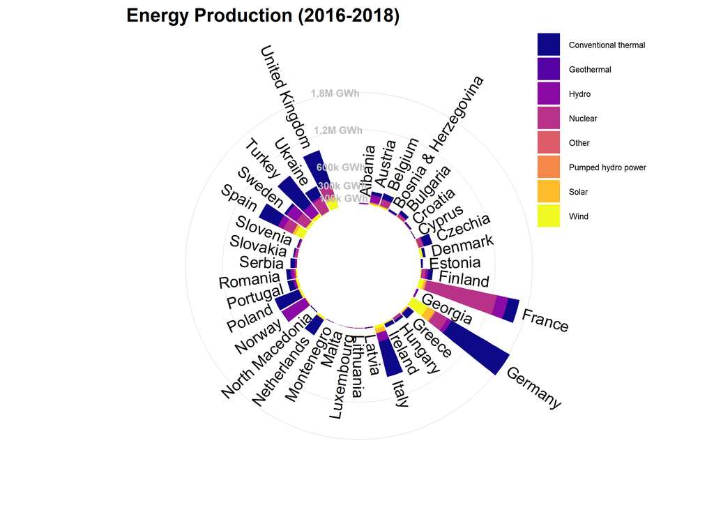

```r
ggplot(types_total) +
  geom_hline(yintercept = 100000,
             color = viridis(n = 8,
                             option = "plasma",
                             direction = -1)[1],
             size = .05,
             alpha = .4) +
  geom_hline(yintercept = 300000,
             color = viridis(n = 8,
                             option = "plasma",
                             direction = -1)[2],
             size = .05,
             alpha = .4) +
  geom_hline(yintercept = 600000,
             color = viridis(n = 8,
                             option = "plasma",
                             direction = -1)[3],
             size = .05,
             alpha = .4) +
  geom_hline(yintercept = 1200000,
             color = viridis(n = 8,
                             option = "plasma",
                             direction = -1)[4],
             size = .05,
             alpha = .4) +
  geom_hline(yintercept = 1800000,
             color = viridis(n = 8,
                             option = "plasma",
                             direction = -1)[5],
             size = .05,
             alpha = .4) +
  geom_bar(aes(x = factor(id),
               y = total,
               fill = type),
           stat = "identity") +
  coord_polar() +
  ylim(-1000000, 2000000) +
  geom_text(data = types_total %>%
              group_by(id) %>%
              mutate(total = sum(total)) %>%
              ungroup() %>%
              distinct(id, .keep_all = TRUE),
            aes(x = factor(id),
                y = total + 100000,
                label = country_name,
                hjust = hjust,
                angle = angle),
            inherit.aes = FALSE) +
  annotate("text",
           x = factor(rep(max(types_total$id), 5)),
           y = c(100000, 300000, 600000, 1200000, 1800000),
           label = c("100k GWh",
                     "300k GWh",
                     "600k GWh",
                     "1.2M GWh",
                     "1.8M GWh"),
           color="gray",
           size=2.5,
           fontface="bold",
           hjust = .7) +
  theme_minimal() +
  labs(title = "Energy Production (2016-2018)") +
  theme(panel.grid = element_blank(),
        axis.title = element_blank(),
        axis.text = element_blank(),
        legend.title = element_blank(),
        legend.text = element_text(size = 6),
        legend.position = c(1, .8),
        axis.ticks = element_blank(),
        title = element_text(face = "bold")) +
  scale_fill_viridis(option = "plasma",
                     discrete = TRUE,
                     direction = 1)
```

And that’s it! Overall, the radial bar graph looks pretty dope, however using the `coord_polar` function seems to mess up the width of the entire plotting window so I’m not sure if the overall effect is really worth it. Anywho, it’s not a bad looking plot. For extra good looks, use `panel.background = element_rect(color = "black", fill = "black")` within the `theme` function for an extra cool effect.

That’s all for this time.

[Daniel](https://dmolitor.com)